# Project 1: Wrangling, Exploration, Visualization

#### Visualizing

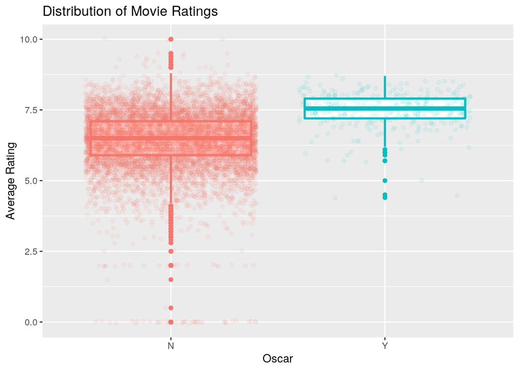

```r
Project_df %>% ggplot(aes(x = Oscar, y = vote_average, color = Oscar)) +
    ylab("Average Rating") + ggtitle("Distribution of Movie Ratings") +
    geom_boxplot(size = 1) + geom_jitter(alpha = 0.08) + theme(legend.position = "none")
```

This plot visually diplays the five number summary for oscar-winning vs non ocar-winning movies (min, max, median, upper and lower quartiles) and an overlay of the true data points. From this we can see that the Oscar-winning movies have a much smaller spread of data and are generally rated higher than non Oscar-winning movies. They also have much fewer outliers.

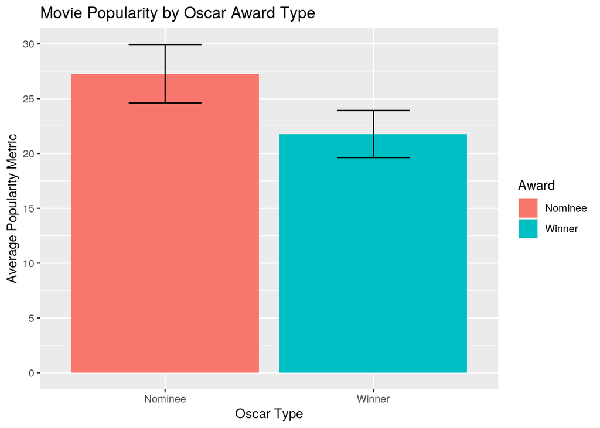

```r
Project_df %>% na.omit() %>% ggplot(aes(x = Award, y = popularity)) +
    geom_bar(aes(fill = Award), stat = "summary", fun = mean) +
    geom_errorbar(stat = "summary", width = 0.35) + ggtitle("Movie Popularity by Oscar Award Type") +
    xlab("Oscar Type") + ylab("Average Popularity Metric") +
    scale_y_continuous(breaks = seq(0, 30, 5))
```

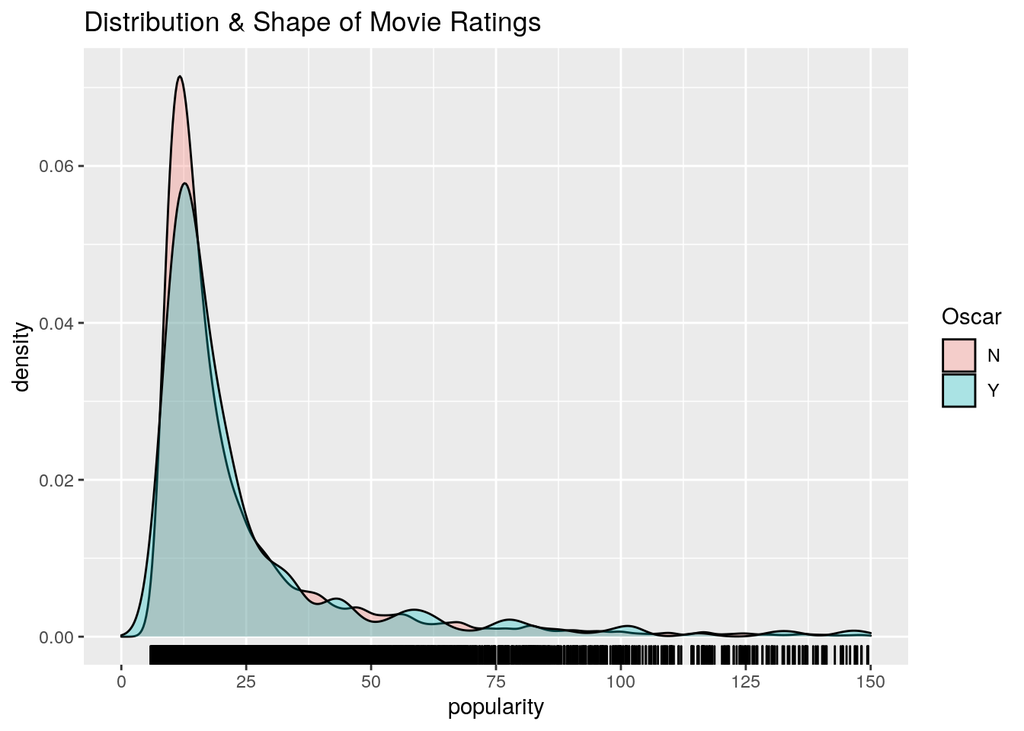

```r
# Project_df %>% na.omit() %>%
# ggplot(aes(x=Year,y=popularity, color=Award)) +
# geom_point() + scale_y_continuous(lim=c(0,150)) +
# scale_x_discrete(breaks = seq(0,2020,10)) +
# geom_smooth(method = lm)

# Project_df %>% na.omit() %>% ggplot(aes(x=Year,
# y=popularity)) + geom_bar(aes(fill=Award),stat='summary',
# fun=mean, position = 'dodge') +
# geom_errorbar(stat='summary', width=.35) + ggtitle('Movie
# Popularity by Oscar Award Type') + xlab('Oscar Type') +
# ylab('Average Popularity Metric')

Project_df %>% ggplot(aes(x = popularity, fill = Oscar)) + ggtitle("Distribution & Shape of Movie Ratings") +
    geom_density(alpha = 0.3) + geom_rug() + scale_x_continuous(lim = c(0,
    150), breaks = seq(0, 150, 25))
```

This plot shows the shape and distribution of movie popularity. Both Oscar winners and non-Oscar winners have a unimodal shape, with a very similar distribution as their graphs overlab almost entirely.

#### Concluding Remarks

Oscar winning or nominated movies are generally just as popular as non-Oscar movies, but Oscar nominees are more popular than Oscar winners.